# RStudio Workshop for S&C Coaches

# Data Visualization

Most times you will want to create visualizations to better understand your analysis and add to reports or to show your players/coaches. For this we are going to use the package **ggplot2** which is loaded with the Tidyverse.

**GGplot** stands for *Grammar of Graphics*. This is one of the most powerful data visualization packages available. You can practically draw any visualization you can imagine. Because it is part of the "Tidyverse" it is already loaded into the script, so you don't have to call it again.

If you want to learn more about **ggplot2** you can visit this [link.](https://ggplot2.tidyverse.org/)

Let's use **playerA4** data frame for the first example. We are going to build a few visuals and tweak them to make them more impactful.

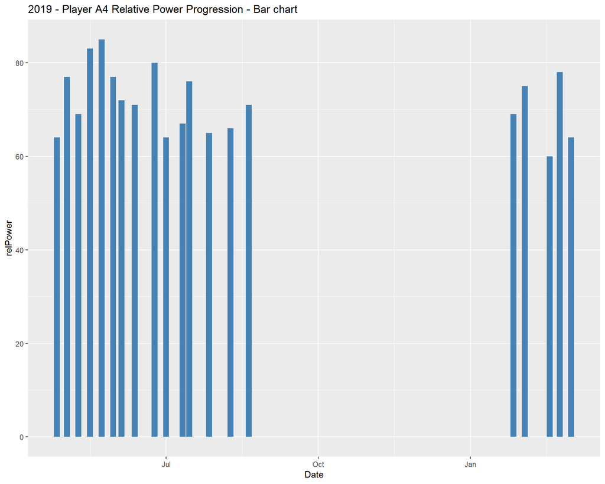

```r
#create bar chart showing the results of all his assessments in 2019

playerA4 %>%

  filter(Date <= "2020-01-01") %>%

  ggplot(aes(x = Date, y = relPower)) +
  geom_bar(fill = "steelblue", stat = "identity", position = "dodge") +
  ggtitle("2019 - Player A4 Relative Power Progression - Bar chart")
```

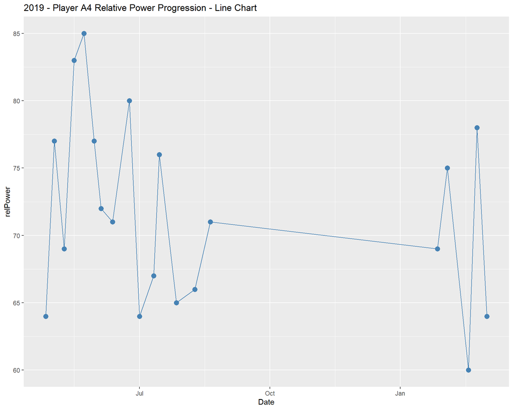

```r
#line chart showing the results of all his assessments in 2019
playerA4 %>%

  filter(Date <= "2020-01-01") %>%

  ggplot(aes(x = Date, y = relPower)) +
  geom_line(color = "steelblue") +
  geom_point(color = "steelblue", size = 3) +
  ggtitle("2019 - Player A4 Relative Power Progression - Line Chart")
```

Let's do other visualizations with the bigger dataset including all players in the sample

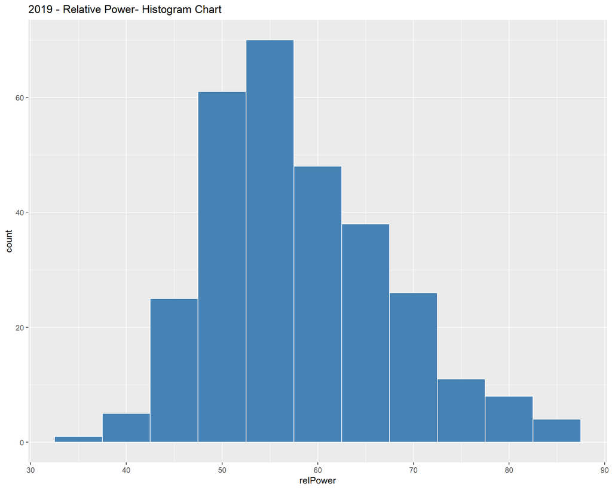

```r
# what is the distribution of the data

plot <- power.c %>%

  filter(Date <= "2020-01-01") %>%

  ggplot(aes(x = relPower)) +
  geom_histogram(fill = "steelblue", color = "white", binwidth = 5) +
  ggtitle("2019 - Relative Power- Histogram Chart")

plot
```

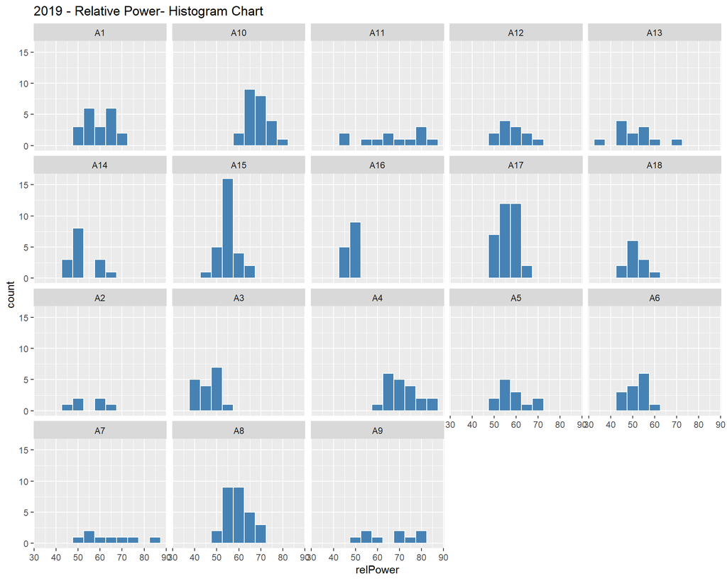

```r
#Facetting by player allows to show smallet graph for each player. This is called small multiples.

plot + facet_wrap(~Player)
```

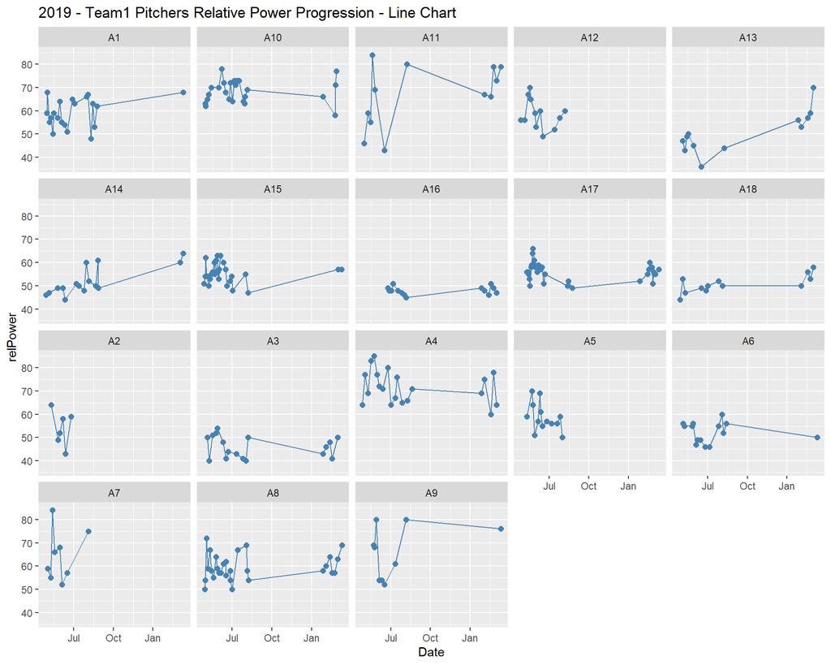

```r
# facetting line charts

power.c %>%

  filter(Date <= "2020-01-01") %>%

  ggplot(aes(x = Date, y = relPower)) +
  geom_line(color = "steelblue") +
  geom_point(color = "steelblue", size = 2) +
  facet_wrap(~Player) +
  ggtitle("2019 - Team1 Pitchers Relative Power Progression - Line Chart")
```

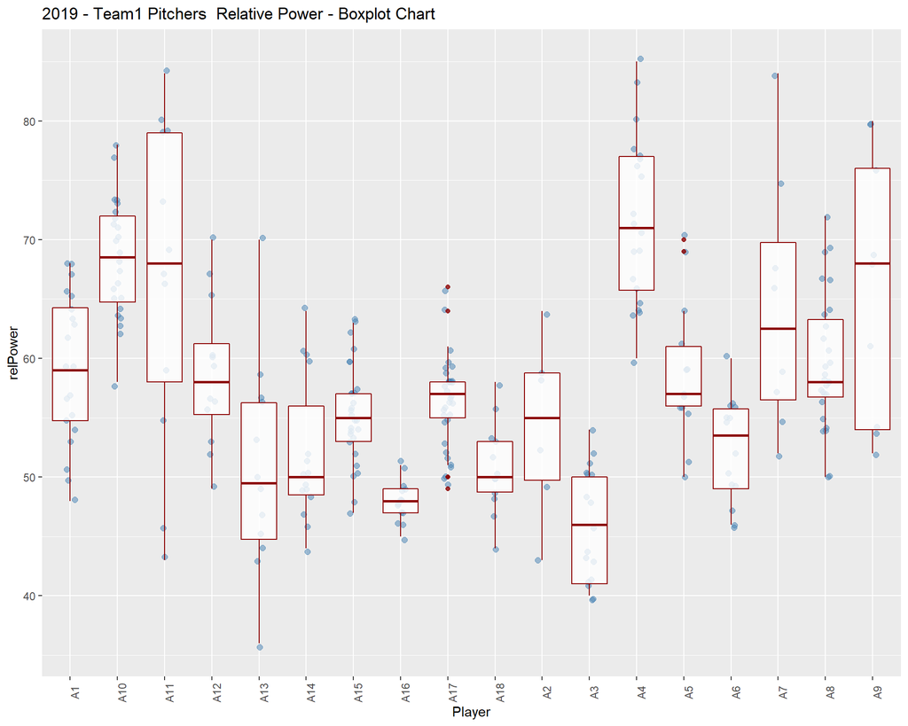

```r
# boxplot chart are a good way to vosualize summaries of your data

power.c %>%

  filter(Date <= "2020-01-01") %>%

  ggplot(aes(x = Player, y = relPower)) +
  geom_jitter(color = "steelblue", size = 2, alpha = 0.5, width = 0.1) +
  geom_boxplot(alpha = 0.8, color = "darkred") +
  ggtitle("2019 - Team1 Pitchers  Relative Power - Boxplot Chart") +
  theme(axis.text.x = element_text(angle = 90))
```

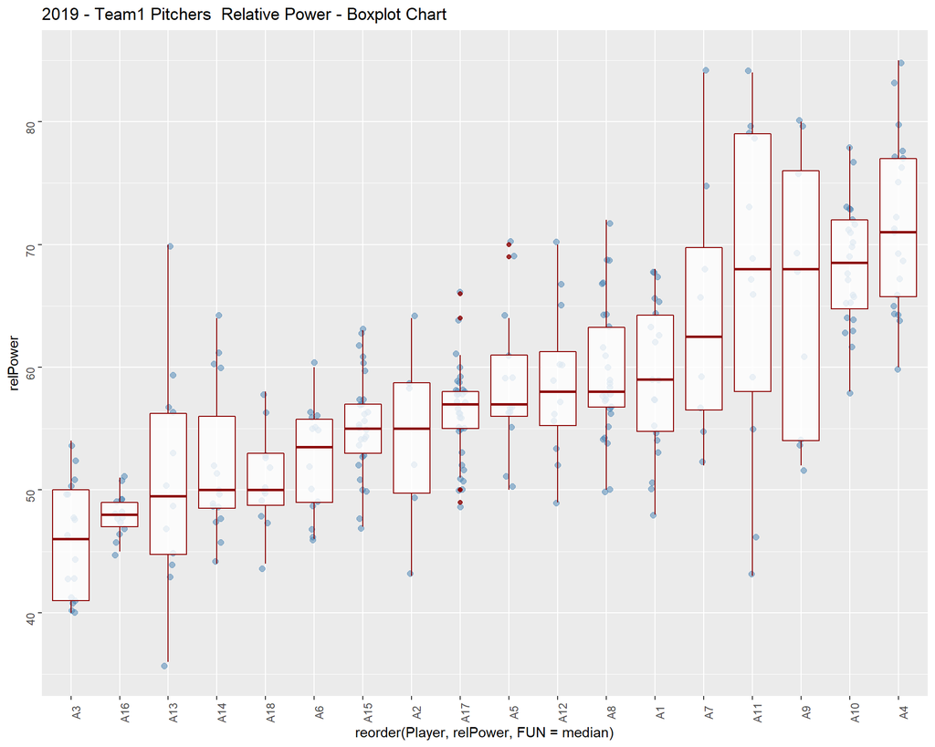

```r
# reorder for better understanding from worse to better

power.c %>%

  filter(Date <= "2020-01-01") %>%

  ggplot(aes(x = reorder(Player, relPower, FUN = median), y = relPower)) +
  geom_jitter(color = "steelblue", size = 2, alpha = 0.5, width = 0.1) +
  geom_boxplot(alpha = 0.8, color = "darkred") +
  ggtitle("2019 - Team1 Pitchers  Relative Power - Boxplot Chart") +
  theme(axis.text = element_text(angle = 90))
```

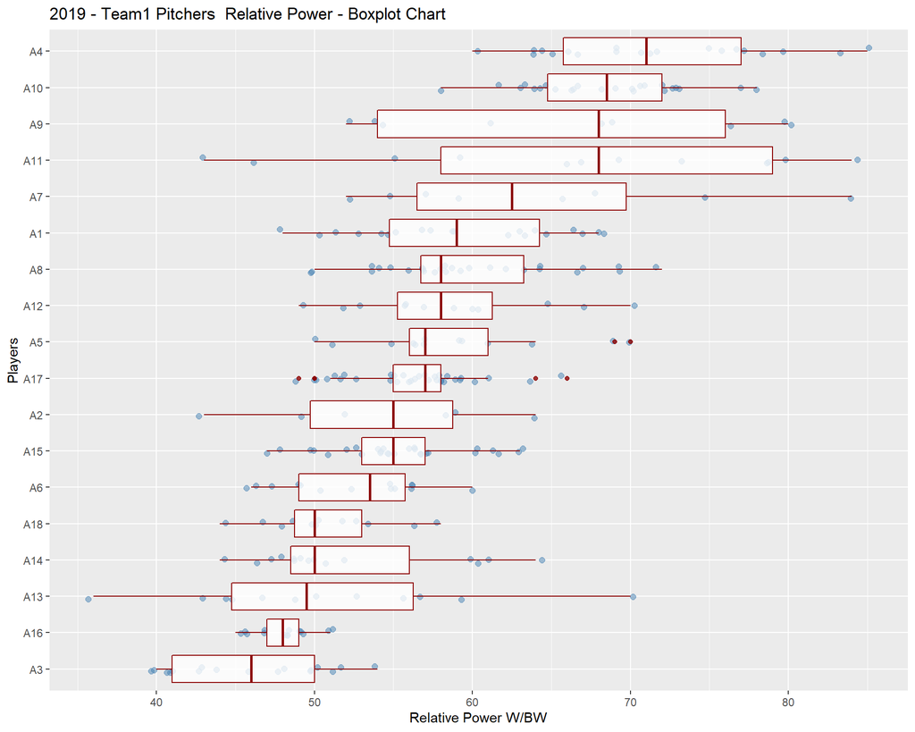

```r
#filp it to make it even easier to understand

power.c %>%

  filter(Date <= "2020-01-01") %>%

  ggplot(aes(x = reorder(Player, relPower, FUN = median), y = relPower)) +
  geom_jitter(color = "steelblue", size = 2, alpha = 0.5, width = 0.1) +
  geom_boxplot(alpha = 0.8, color = "darkred") +
  coord_flip() +
  ggtitle("2019 - Team1 Pitchers  Relative Power - Boxplot Chart") +
  ylab("Relative Power W/BW") +
  xlab("Players")
```

# Joining different datasets

More often than not you will need to work with different datasets. So you will have to join data from different sources. We can achieve this using **join** statements. In the following code we are going to join our 3 data sets: Strength, Power and Speed. We will call the new dataset "all.data".

Notice how all 3 datasets have a common variable (Player) which will be the common column we will use for joining.

```r
#first let's remove the date columns as we won't use it

st <- strength.C %>% group_by(Player) %>% summarise(maxStrength = max(maxStrength))
po <- power.c %>% group_by(Player) %>% summarise(maxPower = max(relPower))
sp <- speed.c %>% group_by(Player) %>% summarise(maxSpeed = max(maxSpeed))

#now let's join the 3 datasets by player

all.data <- full_join(st, po, by = c("Player")) %>% full_join(sp, by = c("Player"))
all.data
```

| Player | maxStrength | maxPower | maxSpeed |
| --- | --- | --- | --- |
| A1 | 516 | 68 | 3.93 |
| A11 | 342 | 84 | 3.75 |
| A12 | 562 | 70 | 4.10 |
| A13 | 484 | 70 | 4.27 |
| A14 | 408 | 64 | 4.00 |
| A15 | 556 | 63 | 3.98 |
| A16 | 375 | 51 | 4.19 |
| A2 | 520 | 64 | 3.95 |
| A3 | 467 | 54 | 3.87 |
| A4 | 440 | 85 | 3.71 |

[output cut: 8 more lines]

```r
#remove the NAs on the data with na.omit()

all.data <- all.data %>% na.omit()
all.data
```

| Player | maxStrength | maxPower | maxSpeed |
| --- | --- | --- | --- |
| A1 | 516 | 68 | 3.93 |
| A11 | 342 | 84 | 3.75 |
| A12 | 562 | 70 | 4.10 |
| A13 | 484 | 70 | 4.27 |
| A14 | 408 | 64 | 4.00 |
| A15 | 556 | 63 | 3.98 |
| A16 | 375 | 51 | 4.19 |
| A2 | 520 | 64 | 3.95 |
| A3 | 467 | 54 | 3.87 |
| A4 | 440 | 85 | 3.71 |

[output cut: 5 more lines]

# Relationships between metrics

As you can see, by joining data from different assessments you can quickly start building physical profiles.

The next step in our data analysis is to start looking into relationships between variables. Let's do that by looking at the correlation between strength and power. We can do this using the function *cor()*, which takes to arguments.

```r
#correlation between power and strength

cor(all.data$maxStrength, all.data$maxPower)
```

```
## [1] 0.06884643
```

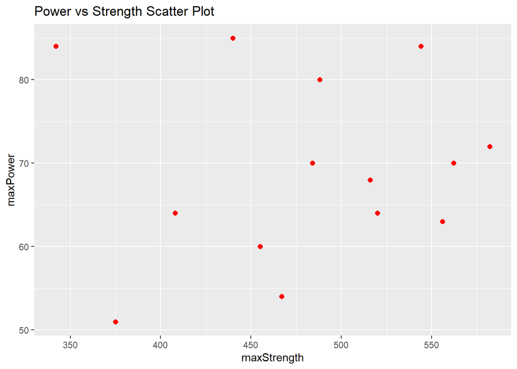

```r
# scatterplot between the two variables

all.data %>%

  ggplot(aes(x = maxStrength, y = maxPower)) +
  geom_point(color = "red", size = 2) +
  ggtitle("Power vs Strength Scatter Plot")
```

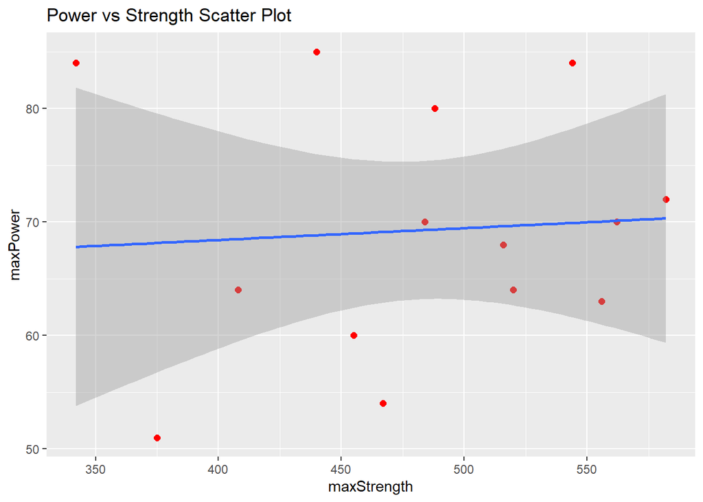

```r
# Let's add a best fit line using geom_smooth

all.data %>%

  ggplot(aes(x = maxStrength, y = maxPower)) +
  geom_point(color = "red", size = 2) +
  geom_smooth(method = "lm") +
  ggtitle("Power vs Strength Scatter Plot")
```

To finish this workshop, let's look at speed vs strength. Remember the data has been altered and de-identified so the correlations will not make sense, but for learning purposes:

```r
#correlation between strength and speed
cor(all.data$maxStrength, all.data$maxSpeed)
```

```
## [1] -0.101134
```

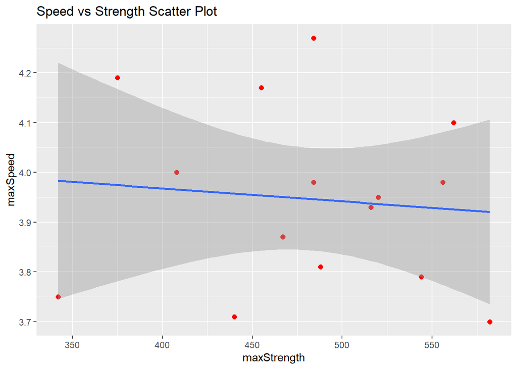

```r
#scatterplot
all.data %>%

  ggplot(aes(x = maxStrength, y = maxSpeed)) +
  geom_point(color = "red", size = 2) +
  geom_smooth(method = "lm") +
  ggtitle("Speed vs Strength Scatter Plot")
```

# What now?

There are a number of resources you can use to continue exploring R. I recommend familiarizing yourself with the **R cheatsheets**. These are one or two pages report containing simple summaries of different functions available within some of the R packages. The following should be useful:

- Data Transformation [Cheatsheet](https://resources.rstudio.com/rstudio-developed/data-transformation)
- GGPLOT [Cheatsheet](https://resources.rstudio.com/rstudio-developed/data-visualization-2-1)
- Importing data [Cheatsheet](https://resources.rstudio.com/rstudio-developed/data-import)

Also, this [video](https://www.youtube.com/watch?v=lL0s1coNtRk) offers a good introduction to RStudio, the platform and different aspects you should familiarize yourself when starting to work in R.

For **GGPLOT** I found [this book](https://ggplot2-book.org/) to be really helpful to get an overall idea of what is possible with this package. The link will take you to a free copy of the book.